# Quandmod-Quantitative Finance R tutorial Youtube

Janis Corona

1/20/2020

This is a youtube tutorial on quant finance from ’Quant Finance with R Part 1 intro and Data": [This tutorial link](https://www.youtube.com/watch?v=uwuPQUa2TjI).

- $install.packages('quantmod')$
- $install.packages('PerformanceAnalytics)$

The above package, quantmod, is used for quantitative finance in R. The PerformanceAnalytics package is used to analyze the data using quantmod in R.

```r
library(quantmod)
library(PerformanceAnalytics)
```

- $?quantmod$
- $?getSymbols$

This sets a minimum date to grab out of the AAPL finance data so that all dates will be after Feb 1, 2017.

```r
dt <- '2017-2-1'

aapl <- getSymbols.yahoo('AAPL', from = dt, auto.assign=F)
```

The above object is an ‘xts’ object or extensible time series object used in financial markets.

```r
head(aapl)
```

```
##            AAPL.Open AAPL.High AAPL.Low AAPL.Close AAPL.Volume AAPL.Adjusted
## 2017-02-01    127.03    130.49   127.01     128.75   111985000      122.9902
## 2017-02-02    127.98    129.39   127.78     128.53    33710400      122.7800
## 2017-02-03    128.31    129.19   128.16     129.08    24507300      123.3054
## 2017-02-06    129.13    130.50   128.90     130.29    26845900      124.4613
## 2017-02-07    130.54    132.09   130.45     131.53    38183800      125.6458
## 2017-02-08    131.35    132.22   131.22     132.04    23004100      126.1330
```

```r
dim(aapl)
```

```
## [1] 746   6
```

```r
row.names(aapl)[1:20]
```

[output not shown]

```r
colnames(aapl)
```

```
## [1] "AAPL.Open"     "AAPL.High"     "AAPL.Low"      "AAPL.Close"
## [5] "AAPL.Volume"   "AAPL.Adjusted"
```

The following are also xts objects.

```r
aaplClose <- aapl[,6]


# use of the PerformanceAnalytics library loaded earlier
appleReturns <- dailyReturn(aaplClose, type='log')

appleReturns1 <- na.omit(dailyReturn(aaplClose, type='log'))
```

```r
head(appleReturns)
```

```
##            daily.returns
## 2017-02-01   0.000000000
## 2017-02-02  -0.001710085
## 2017-02-03   0.004269986
## 2017-02-06   0.009330424
## 2017-02-07   0.009471964
## 2017-02-08   0.003870171
```

```r
head(appleReturns1)
```

```
##            daily.returns
## 2017-02-01   0.000000000
## 2017-02-02  -0.001710085
## 2017-02-03   0.004269986
## 2017-02-06   0.009330424
## 2017-02-07   0.009471964
## 2017-02-08   0.003870171
```

The NAs should have been removed but are being read in as zeros, from quantmod when getting the ‘AAPL’ xts object from the web.

The following will chart a graph of the xts object, aapl.

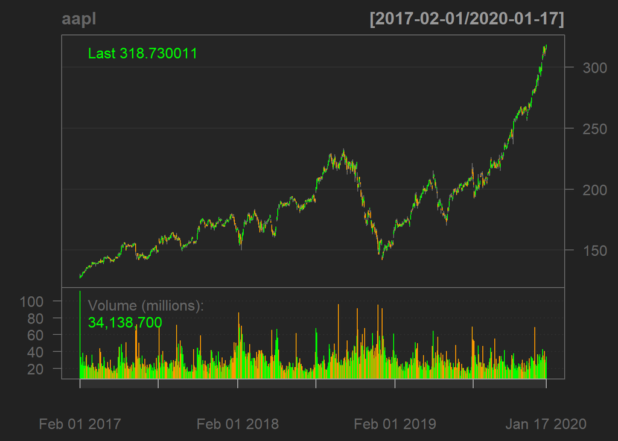

```r
chartSeries(aapl)
```

[Quant Finance with R Part 2: Portfolio Analysis](https://www.youtube.com/watch?v=2Y4HX0UUcrA): (https://www.youtube.com/watch?v=2Y4HX0UUcrA) of 4 parts for this Quantitative Finance tutorial on Youtube from December 2018.

```r
library(quantmod)
library(PerformanceAnalytics)
```

Function that uses the closing price column to add the prices since a set date.

```r
tickers <- c('FB', 'AAPL','NFLX')

weights <- c(0.25, 0.25, 0.25)

portfolioPrices <- NULL

for (ticker in tickers){
  portfolioPrices <- cbind(portfolioPrices, getSymbols.yahoo(ticker,
  from = '2016-01-03', periodicity='daily', auto.assign=FALSE)[,4])

}
```

Check NAs not in data.

```r
colSums(is.na(portfolioPrices))
```

```
##   FB.Close AAPL.Close NFLX.Close
##          0          0          0
```

S&P benchmark

```r
benchmarkPrices <- getSymbols.yahoo('^GSPC', from='2016-01-03', periodicity='daily', auto.assign=FALSE)[,4]
```

Calculate daily change in each column.

```r
benchmarkReturns <- na.omit(ROC(benchmarkPrices))
colSums(is.na(benchmarkReturns))
```

```
## GSPC.Close
##          0
```

```r
portfolioReturns <- na.omit(ROC(portfolioPrices))
colSums(is.na(portfolioReturns))
```

```
##   FB.Close AAPL.Close NFLX.Close
##          0          0          0
```

```r
portfolioReturn <- Return.portfolio(portfolioReturns)
```

To find out more on the Return.portfolio function, use: * $?Return.portfolio$

Some side information about a few financial algorithms:

- **CAPM**: formula for expected return with calculated risk on an asset or stock.
- **ALPHA**: risk adjustment metric for performances compares to an index and shows how much better that index is beat by your benchmark.
- **BETA**: measure of volatility with <1 => less risky and >1 => more risky.
- **SHARPE RATIO**: risk metric for every standard deviation unit, how much return is achieved, gives risk & reward, and most widely used metric with finance managers.

The number of trading days is 252 days a year.

```r
CAPM.beta(portfolioReturn, benchmarkReturns, 0.035/252)
```

```
## [1] 1.391641
```

```r
CAPM.jensenAlpha(portfolioReturn, benchmarkReturns, 0.035/252)
```

```
## [1] 0.0524188
```

```r
SharpeRatio(portfolioReturn, 0.035/252)
```

```
##                               portfolio.returns
## StdDev Sharpe (Rf=0%, p=95%):        0.05044925
## VaR Sharpe (Rf=0%, p=95%):           0.03085222
## ES Sharpe (Rf=0%, p=95%):            0.01879745
```

```r
table.AnnualizedReturns(portfolioReturn)
```

|  | portfolio.returns |
| --- | --- |
| Annualized Return | 0.2242 |
| Annualized Std Dev | 0.2473 |
| Annualized Sharpe (Rf=0%) | 0.9067 |

```r
table.CalendarReturns(portfolioReturn)
```

[output not shown]